# hw5_mark

Ruizhou Peng

2023-11-12

first load packages

```r
library(tidyverse)
```

## 1. conditional probability, bayes rule and independence

### 1.1 Bayes theroem

q1:

$$\because\mathbb{P}(A)=0.9 \quad \mathbb{P}(B|A)=0.8\\
\therefore\mathbb{P}(A\cap B) = 0.72\\
\because\mathbb{P}(B|A^c)=1-\mathbb{P}(B^c|A^c)=0.25\\
\therefore\mathbb{P}(B)=\mathbb{P}(B|A^c)*\mathbb{P}(A^c)+\mathbb{P}(B|A)*\mathbb{P}(A)=0.745\\
so \quad \mathbb{P}(A|B)=\frac{\mathbb{P}(A\cap B)}{\mathbb{P}(B)}=0.966$$

### 1.2 conditional probabilities

q1:

1. $\because A\subset B \quad \therefore\mathbb{P}(A|B)=\frac{\mathbb{P(A)}}{\mathbb{P}(B)}$ if $\mathbb{P}(B\backslash A)=0$, then $\mathbb{P}(A|B)=1$
2. $\mathbb{P}(A|B)=0 \quad if \space A\cap B = \emptyset$, if $\mathbb{P}(A\cap B)=0$, then except for the case before, it also may because $\mathbb{P}(A)=0 \quad or \quad \mathbb{P}(B)=0$ in these cases, if one event probability is 0, then the probability for both events happen is also 0. it still holds
3. $\mathbb{P}(A|B)=\frac{\mathbb{P}(B)}{\mathbb{P}(B)}=1$
4. yes, $\mathbb{P}(A|\Omega)=\frac{\mathbb{P}(A\cap \Omega)}{\mathbb{P}(\Omega)}=\frac{\mathbb{P}(A)}{1}=\mathbb{P}(A)$
5. $\mathbb{P}(B|A\cap C)=\frac{\mathbb{P}(B\cap A \cap C)}{\mathbb{P}(A\cap C)}\\\mathbb{P}(A\cap C)=\mathbb{P}(A|C)\mathbb{P}(C)\\so \quad \mathbb{P}(B\cap A \cap C)=\mathbb{P}(B|A\cap C)\mathbb{P}(A|C)\mathbb{P}(C)$
6. $\mathbb{P}(A|B\cap C)*\mathbb{P}(B|C)*\mathbb{P}(C)= \mathbb{P}(B\cap A \cap C) = \mathbb{P}(B|A\cap C)\mathbb{P}(A|C)\mathbb{P}(C)\\\mathbb{P}(A|B\cap C)=\frac{\mathbb{P}(B|A\cap C)\mathbb{P}(A|C)}{\mathbb{P}(B|C)}$

q2:

suppose the weather is windy is event A. flight being canceled is event B

1. P(B|A) = 0.3
2. P(B|A<sup>c</sup>) = 0.1
3. P(A) = 0.2

calculate P(B<sup>c</sup>):

$$\because\mathbb{P}(A^c) = 0.8\\
\therefore\mathbb{P}(B) =
\mathbb{P}(A^c)*\mathbb{P}(B|A^c)+\mathbb{P}(A)*\mathbb{P}(B|A)=0.14\\
\therefore \mathbb{P}(B^c) = 0.86$$

### 1.3 mutual independence and pair-wise independence

q1: pair-wise independent

$$A\cap B = \{(1,1,0)\}\\
\mathbb{P}(A\cap B) = \frac{1}{4}=\mathbb{P}(A)\mathbb{P}(B)$$

same reason for $\mathbb{P}(A\cap C) = \mathbb{P}(A)\mathbb{P}(C)$ and $\mathbb{P}(B\cap C) = \mathbb{P}(B)\mathbb{P}(C)$

q2: mutually independent

$$A \cap B \cap C = \emptyset\\
\mathbb{P}(A \cap B \cap C)=0\ne\mathbb{P}(A)\mathbb{P}(B)\mathbb{P}(C)$$

so A,B,C not mutually independent

### 1.4 the monty hall problem

q1:

q2:

## 2. random variables and discrete random variables

### 2.1 expectation and variance

q1: suppose X and Y are independent random variables, prove Cov(X,Y) = 0

ans:

for a given random variable A<sub>i</sub>, let $f_i(A_i) = A_i - \tilde{A_i}$
$$\because X,Y \; are \; independent\\
\therefore E(f_1(X)f_2(Y)) = E(f_1(X))E(f_2(Y))\\
\because f_1(X) = X-\tilde{X},\quad f_2(Y)=Y-\tilde{Y}\\
E[f_1(X)] = E[X-E(X)]=E(X)-E(X)=0\\
E[f_2(Y)] = E[Y-E(Y)]=E(Y)-E(Y)=0\\
\therefore
Cov(X,Y)=E[(X-\tilde{X})(Y-\tilde{Y})]\\=E(f_1(X)f_2(Y))=E(f_1(X))E(f_2(Y))
= 0$$

given ans:

$$Cov(X,Y) = E[(X-\tilde{X})(Y-\tilde{Y})]\\=E[XY]-E[X]E[Y]\\
let\; f_i=x_i\\
E[XY]=E[f_1(X)f_2(Y)]=E[f_1(X)]E[f_2(Y)]=E[X]E[Y]\\
so \; Cov(X,Y)=0$$

### 2.2 distribution

q1:

1. probability mass function $p_X$ is:

$$p_X(X) = \begin{cases}
1-\alpha-\beta, \quad X=0\\
\alpha, \quad X=3\\
\beta, \quad X=10\\
0, otherwise
\end{cases}$$

2. expectation of X:

$$E(X) = 0*P(X=0)+3*P(X=3)+10*P(X=10)\\
=3\alpha+10\beta$$

3. variance of X: note that $E(\tilde{X})=\tilde{X}$

$$Var(X) = E[(X-\tilde{X})^2]=E[X^2]-E(X)^2\\
=9\alpha+100\beta-9\alpha^2-100\beta^2-60\alpha\beta$$

4. standard deviation of X:

$$Std(X) = \sqrt{Var(X)}\\
=\sqrt{9\alpha+100\beta-9\alpha^2-100\beta^2-60\alpha\beta}$$

q2: distribution and distribution function

1. distribution P<sub>X</sub> of X:

$$P(X) =
(1-\alpha-\beta)\mathbf{1}_X(0)+\alpha\mathbf{1}_X(3)+\beta\mathbf{1}_X(10)$$

2. distribution function F<sub>X</sub> of X:

$$F_X(x)=\mathbb{P}(X\le x)\\
F_X(x)= \begin{cases}
0, \quad -\infty\le x<0\\
1-\alpha-\beta, \quad 0\le x<3\\
1-\beta, \quad 3\le x < 10\\
1, \quad 10 \le x
\end{cases}$$

q3: variance and covariance

$$Var(Y) = Var(X_1+X_2+X_3+X_4...+X_n)\\
=\sum_{i=1}^nVar(X_i)\\
=n(9\alpha+100\beta-9\alpha^2-100\beta^2-60\alpha\beta)$$
q4: explore the distribution of the sum of n independent random variables when n is large

since X<sub>1</sub>, X<sub>2</sub>,…,X<sub>n</sub> are discrete, the values of each variable are only integer, so the combination values of these variables are also integer(say, discrete). Therefore, the random variable Y is discrete

let Y be X<sub>1</sub>+X<sub>2</sub>+X<sub>3</sub>+…+X<sub>n</sub>. $\alpha=0.2$ and $\beta=0.3$

step1:

write a function called **Gen_X_numbers**, taking a number n as input and return a vector containing n random numbers from the distribution of X

first generate a random number from the uniform distribution of [0,1], if number is in [0, 0.5), assign 0, otherwise, from [0.5, 0.7) assign 3, [0.7, 1] assign 10

```r
# use runif to generate a random deviate

Gen_X_numbers <- function(n){
  # n is the number of elements
  # return a vector

  vec <- runif(n, 0, 1)
  #print(vec)
  vec[vec<0.5] = 0
  vec[0.5<=vec & vec<0.7] = 3
  vec[0.7<=vec & vec<=1] = 10

  return(vec)
}
```

check

```r
Gen_X_numbers(4)
```

```
## [1] 10 10  0  0
```

step2:

write a function **Gen_Y_samples** taking two arguments as input and returning a data frame. The function should take *m* and *n* as input and return a data frame which has a column named Y and m rows, each row the value of Y is the sum of vector<sub>X</sub>

```r
Gen_Y_samples <- function(m,n){
  # m is the rows of Y
  # n is the number of variable X

  index <- seq(1,m)

  compute_one_Y <- function(n){
    X_seq <- Gen_X_numbers(n)
    # print(sum(X_seq))

    return(sum(X_seq))
  }

  # attention!
  # map_dbl the second argument is a function
  # if use compute_one_Y(n), it is a function call
  # and return is a number not a function
  # so we need to use "~" to pass index to it
  # although we don't need it
  Y <- map_dbl(index, ~compute_one_Y(n))
  # print(Y)
  return(data.frame(index,Y))
}
```

check

```r
Gen_Y_samples(5,2)
```

```
##   index  Y
## 1     1 10
## 2     2 13
## 3     3  0
## 4     4  3
## 5     5 10
```

step3:

let n = 3 and m = 50000, use bar plot to show the samples of Y

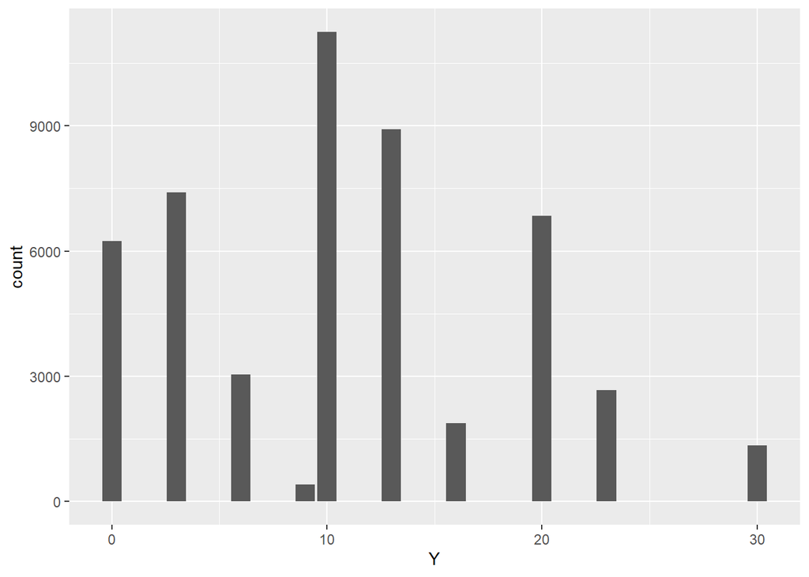

```r
df_sample <- Gen_Y_samples(50000, 3)

# use bar to count number
# col is different using x,y aes to show other metrics
df_sample %>% ggplot(aes(x=Y))+
  geom_bar()
```

step4:

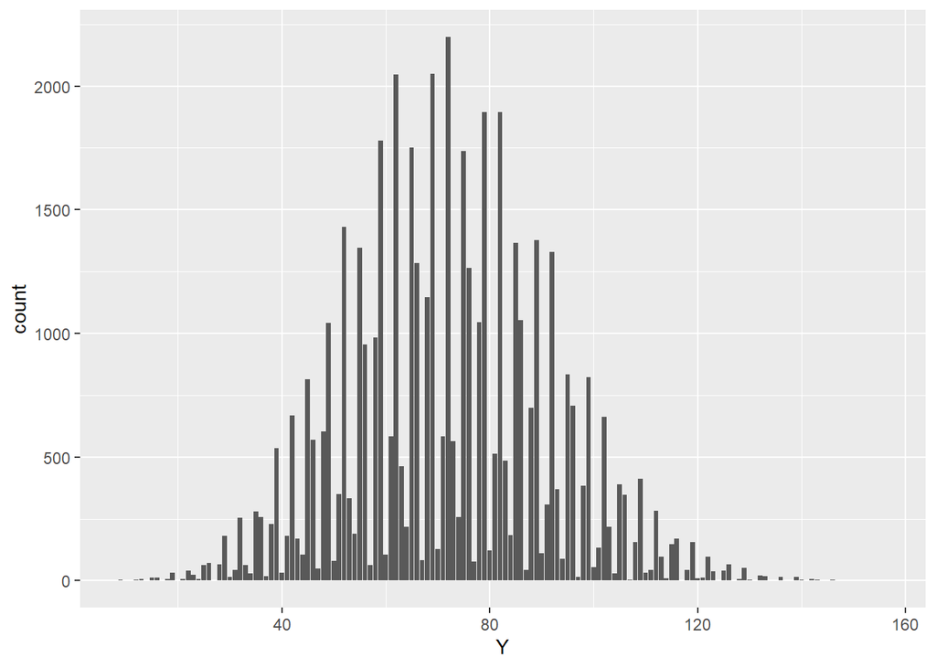

```r
df_sample <- Gen_Y_samples(50000, 20)

# use bar to count number
df_sample %>% ggplot(aes(x=Y))+
  geom_bar()
```

show the maximum and minimum:

```r
max(df_sample$Y)
```

```
## [1] 156
```

```r
min(df_sample$Y)
```

```
## [1] 9
```

```r
range(df_sample$Y)
```

```
## [1]   9 156
```

```r
diff(range(df_sample$Y))
```

```
## [1] 147
```

step5:

increase n to 1000, E(X) = 3*0.2+10*0.3 = 3.6, E(Y) = n*E(X) = 3600

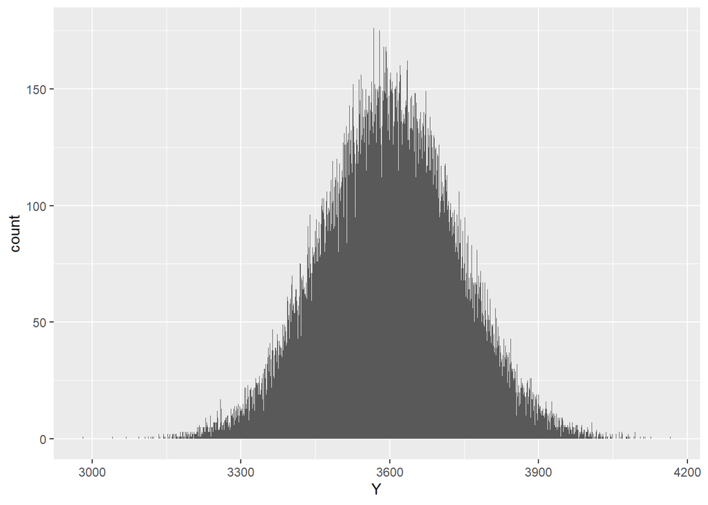

```r
df_sample <- Gen_Y_samples(50000, 1000)

# use bar to count number
df_sample %>% ggplot(aes(x=Y))+
  geom_bar()
```

show the maximum and minimum:

```r
max(df_sample$Y)
```

```
## [1] 4166
```

```r
min(df_sample$Y)
```

```
## [1] 2982
```

```r
range(df_sample$Y)
```

```
## [1] 2982 4166
```

```r
diff(range(df_sample$Y))
```

```
## [1] 1184
```